# Introduction to Module and C++

6G5Z0025 Computer Graphics

Dr Jon Shiach

Department of Computing and Mathematics

Week 1

# Module Information

**Learning Outcomes**

1. Select and use appropriate mathematical tools for constructing and manipulating geometry in 3D space
2. Develop an interactive 3D graphics application using an industry-standard API
3. Write shader code for the programmable pipeline on modern graphics hardware using an industry standard shader language

# About me

- Dr Jon Shiach
- Email: j.shiach@mmu.ac.uk
- Office: DB 3.27
- Office hours: TBC (see Moodle)

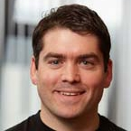

# Teaching Schedule

| Week | Date (Monday) | Content |
| --- | --- | --- |
| 1 | 27/01/25 | Introduction to module |
| 2 | 03/02/25 | Basic shapes in OpenGL |
| 3 | 10/02/25 | Textures |
| 4 | 17/02/25 | Vectors and matrices |
| 5 | 24/02/25 | Transformations |
| 6 | 03/03/25 | 3D Worlds |
| 7 | 10/03/25 | Moving the camera |
| 8 | 17/03/25 | Lighting |
| 9 | 24/03/25 | Normal mapping |
| 10 | 31/03/25 | Quaternions |
| 11 | 07/04/25 | Consolidation and round-up |

# Super Mario Bros - 1985

[figure not shown]

- Just 40 KB
- Clever use of repeated sprites

## Elite – 1984

[figure not shown]

- Early 3D graphics

## Doom – 1993

[figure not shown]

- Pseudo 3D first-person shooter
- First use of tree data structures to deal with hidden surface removal

## Quake – 1996

[figure not shown]

- First fully 3D first-person shooter

## Tomb Raider – 1996

[figure not shown]

- First use of quaternions to allow for third-person camera view

## The Last of Us Part II – 2020

[figure not shown]

- Use of motion capture for character animations (not the first game to do this, just my favourite)

# Definitions

- **Pixel** – a single indivisible square that are combined to form an image on a display
- **Raster** – a grid of pixels
- **Fragment** – a section of a raster
- **Buffer** – a region of memory used to store data
- **Frame** – a single image shown on a display
- **Frame buffer** – the memory required to store a frame
- **Refresh rate** – number of times per second the display shows another frame

[figure not shown]

# RGB Colour Model

- Different levels of the three primary colours Red, Green and Blue provide colours
- 3-bit colour (1 bit of each primary colour) produces $2^1 \times 2^1 \times 2^1 = 8$ different colours

| Red | Green | Blue | Colour |  |
| --- | --- | --- | --- | --- |
| 0 | 0 | 0 | Black | ◼ |
| 0 | 0 | 1 | Blue | ◼ |
| 0 | 1 | 0 | Green | ◼ |
| 0 | 1 | 1 | Cyan | ◼ |
| 1 | 0 | 0 | Red | ◼ |
| 1 | 0 | 1 | Magenta | ◼ |
| 1 | 1 | 0 | Yellow | ◼ |
| 1 | 1 | 1 | White | ◼ |

# 24-bit colour

- 24-bit colour, 8 bits of each primary colours produces $2^8 \times 2^8 \times 2^8 = 16,777,216$ different colours
- The human eye can detect approximately 10 million colours so 24-bit colour is good enough (known as *True colour*)
- The size of a **frame buffer** for a $1920 \times 1080$ raster using a colour depth of 32 bits per pixel (24-bits for colour, 8-bits for opacity) is

$$\begin{align*}
\text{frame buffer size} &= \text{width} \times \text{height}
\times \text{bits per pixel} \\
&= 1920 \times 1080 \times 32 \text{ bits} \\
&= 66,355,200 \text{ bits} \\
&= 8.3 \text{ MB}
\end{align*}$$

- So everytime the display is refreshed we need to transfer 8.3MB of data

# 3D Graphics

- 3D graphics are defined using geometric co-ordinates $(x, y, z)$
- To display 3D graphics on a 2D display we need to do:
  - determine the position of a virtual camera (usually using keyboard and mouse inputs)
  - determine the co-ordinates of the objects in the 3D space relative to the camera
  - project the 3D co-ordinates onto a 2D plane taking into account depth perspective
  - determine the colours of the fragments that make up each 3D object and send this information to the display
- All calculations and data transfer must be done within a required refresh rate – usually 30 or 60 fps

# Hardware

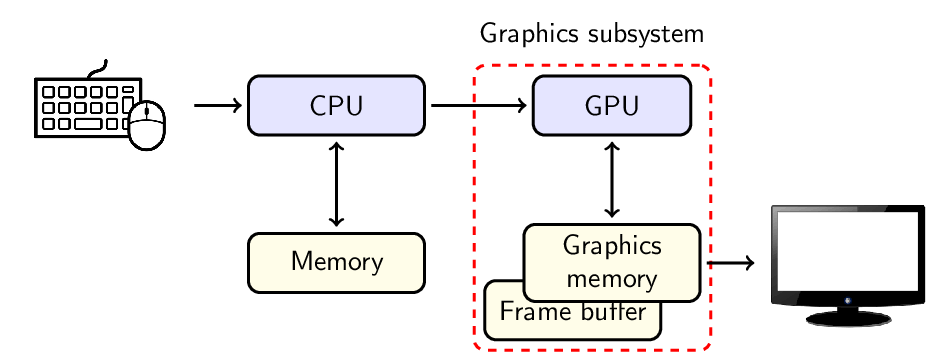

# Graphics API

- A **graphics API** is a set of tools, functions and procedures that allow us to interact with our graphics hardware
- Some popular graphics APIs are:
  - **OpenGL** – a cross-platform graphics API originally developed by Silicon Graphics in the early 1990s (then called Iris GL), it is now open source and maintained by the Khronos Group
  - **Vulkan** – developed by the Khronos group to be a successor to OpenGL. Released in 2016 Vulkan is a low level API meaning much of the memory management is left to the developer
  - **DirectX** – developed by Microsoft (hence the Xbox) in the early 1990s and maintained to this day with Direct3D 12. Limited to Windows and Xbox
  - **Metal** – developed by Apple and limited to macOS, iOS and iPadOS
- We will be using OpenGL as it’s the industry standard cross-platform and there is lots of guidance material available

# Why C++?

- We need a language that is:
  - mature and well established
  - fast at performing calculations, accessing system devices, manipulating memory
  - supported by the graphics API
- C++ is the obvious choice
  - Originally created to write operating systems so all device drivers and OS resources are written in it
  - Platform independent - same code will work on Windows, macOS and Linux
  - Object orientated - easy to import and use libraries

# How C++ Works

- **Source code** – C++ files (.cpp) and header files (.hpp) written by the programmer
- **Compiler** – converts C++ code into machine code
- **Linker** – links compiled C++ code to external resources
- **Executable** – an application (executable program) or library (reusable resource)
- Compiler and linker are specific to each hardware platform.

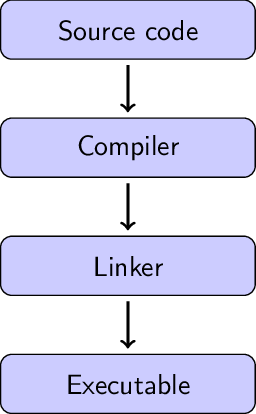

# C++ Variables

| Type | Description |
| --- | --- |
| `int` | integer, e.g., `1`, `-2`, `0` |
| `unsigned int` | positive integers only, e.g., `1`, `2`, `3` |
| `float` | floating point numbers, e.g., `1.23f` |
| `double` | double floating point |
| `char` | single character, e.g., `a` |
| `string` | text consisting of multiple characters, e.g., `hello world` |
| `bool` | Boolean values, e.g., `true` or `false` |

# Operators

| Operator | Description | Example |
| --- | --- | --- |
| `=` | Assignment operator | `a = 5;` |
| `+`, `-`, `*`, `/` | Standard arithmetic operators | `b = 2 * a;` |
| `%` | Modulo (remainder) | `x % 2;` |
| `+=`, `-=`, `*=`, `/=` | Compound operators | `a *= 2;` |
| `++`, `--` | Indcrement and decrement | `a++;` |
| `==`, `!=` | Logical equals/not equals | `a != 2;` |
| `<`, `>`, `>=`, `<=` | Greater/less than | `a <= 2;` |
| `&&`, `\|\|` | Logical and/or | `a == 2 && y > 4;` |

# Hello World

```cpp
#include <iostream>

int main()
{
    std::cout << "hello world" << std::endl;
    return 0;
}
```

- All C++ programs need a `main()` function
- All C++ functions need an output specifier, e.g., `int`, `float`, `void` etc
- All C++ expressions must end with a semi-colon `;`
- `iostream` – standard input/output library
  - `std::cout` – standard output stream
  - `<<` – insertion operator
  - `std::endl` – new line and flushes output stream

# If-Else

```cpp
if (condition1)
{
    // code to be executed if condition1 is true
}
else if (condition2)
{
    // code to be executed if condition1 is false and condition2 is true
}
else
{
    // code to be executed if both condition1 and condition2 are false
}
```

Curly braces are not needed for single line code within an if statement, e.g.,

```cpp
if (condition)
    // single line to be executed if condition is true
```

# For Loops

```cpp
for (before statement ; condition ; after statement)
{
    // block of code to be executed
}
```

```cpp
for (int i = 0; i < 10; i++)
    std::cout << i << std::endl;
```

Will print out the numbers 0 to 9

# While Loops

```cpp
while ( condition )
{
    // block of code to be executed
}
```

```cpp
do {
    // block of code to be executed
}
while ( condition ) ;
```

- While loops are used for when we don’t know when the loop will be terminated beforehand

# Arrays

```cpp
// Array of integers
int array[] = {1 , 2 , 3 , 4};

// Array of floats
float floatArray[] = {1.0 f , 2.0 f , 3.0 f , 4.0 f };

// Indexing arrays
int firstElement = array[0];

// Memory used for array
unsigned int memory = sizeof(array) ;
```

# The Labs

- You will be doing practical hands on stuff in the lab sessions
- The lab materials are avaialble online at https://jonshiach.github.io/graphics-notes (see Moodle)
- Download the template files from GitHub
- Each lab is a code along where you will be exposed to various techniques and have they are implemented in your program
- The labs use code from previous labs, so you will need to make sure you are up-to-date
- It’s not a race, work at your own pace and help each other